# Health Care Analytics - OpenMRS Analysis

October 24, 2018

## Outline

- Outcomes
- Data
- Tools Used
- Discovery Process
- Changes to the Data
- Analysis
- Challenges
- Recommendations

## Outcomes

- Give better understanding of `openmrs` tables and the study that was performed.
- Show how different stages of HIV effect the blood and the body's ability to fight disease.

## The Data

I used relevant tables and columns from the `openmrs` database. The tables I found important were related to the patient information and observation information.

Useful information was sparse in the data. I was able to use between 10 and 15 percent of ~11,000 instances for analysis.

## Tools Used

- `R` for analysis and connecting to `Access` database
- `R` packages used: `tidyverse`, `RODBC`, `lubridate`, `scales`
- `R Markdown` for presentation
- Tables Used:

```r
#====data frames used====
dfs <- sapply(.GlobalEnv, is.data.frame)
dfs <- dfs[dfs == T]
names(dfs)
```

```
## [1] "mrs_obs"             "mrs_encounter_type"  "mrs_encounter"
## [4] "mrs_patient_program" "mrs_concept"         "mrs_patient"
## [7] "mrs_program"         "mrs_tribe"
```

## Discovery Process

- Counted *patient return* and *return rype* by combining `mrs_encounter` with `mrs_encounter_type`
- Found out what patients were in what programs by combining `mrs_patient_program` with `mrs_program`
- Subset-ed `mrs_obs` into multiple tables: `df_value`, `df_rash`, `df_diagnosis`, `df_tb`, and `df_test`
- Joined `mrs_tribe` to `mrs_patient`

## Discovery Process (cont'd) - Encounter Table

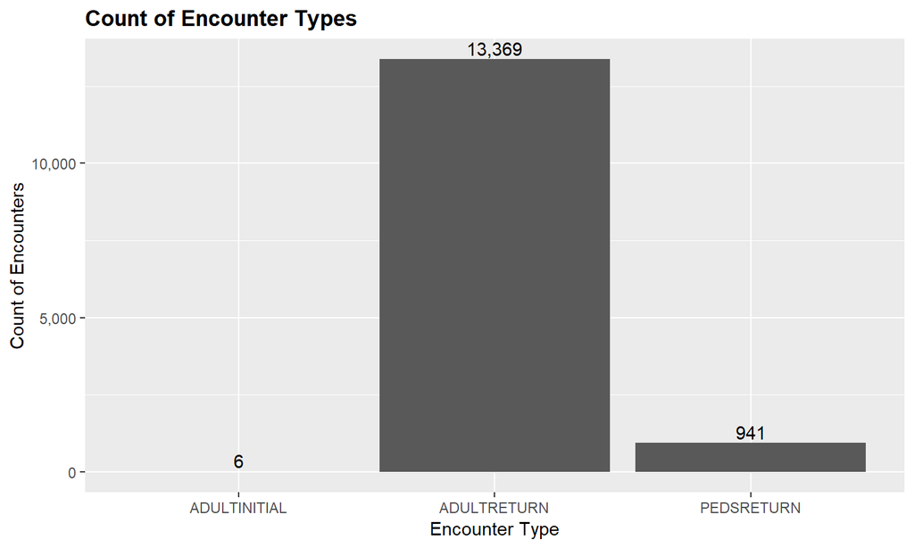

## Discovery Process (cont'd) - Encounter Table

Closer look at `ADULTINITIAL`

```
##   patient_id encounter_type_name n
## 1         39        ADULTINITIAL 3
## 2       3952        ADULTINITIAL 1
## 3       5587        ADULTINITIAL 1
## 4       7107        ADULTINITIAL 1
```

## Discovery Process (cont'd) - Encounter Table

Closer look at patients who were noted as `ADULTINITIAL`

```
##   patient_id encounter_type_name n
## 1         39        ADULTINITIAL 3
## 2         39         ADULTRETURN 8
## 3       3952        ADULTINITIAL 1
## 4       5587        ADULTINITIAL 1
## 5       5587         ADULTRETURN 6
## 6       5587          PEDSRETURN 1
## 7       7107        ADULTINITIAL 1
## 8       7107         ADULTRETURN 2
```

## Discovery Process (cont'd) - Encounter Table

Patient Return Spread (w/o `ADULTINITIAL`)

```
##    number_of_returns freq_patients_returning
## 1                  1                     589
## 2                  2                    1398
## 3                  3                    1327
## 4                  4                    1019
## 5                  5                     243
## 6                  6                      69
## 7                  7                      20
## 8                  8                       9
## 9                  9                       5
## 10                10                       3
## 11                11                       1
```

## Discovery Process (cont'd) - Program Table

How Many People in Each Program

```
##      program_in    n freq
## 1   HIV Program 2678 0.77
## 2 Both Programs  422 0.12
## 3    TB Program  399 0.11
```

## Discovery Process (cont'd) - Observation Table

- Joined to the `mrs_concept` table by `concept_name` and `value_coded`
- Subset-ed `mrs_obs` into multiple tables: `df_value`, `df_rash`, `df_diagnosis`, `df_tb`, and `df_test`

## Discovery Process (cont'd) - Observation Table

HIV Discrepancies

```
##   encounter_id n
## 1         6379 2
```

```
##   encounter_id patient_id hiv_stage
## 1         6379       5830         1
## 2         6379       5830         3
```

## Discovery Process (cont'd) - Observation Table

Counted `numeric` concept types & Removed `concept_name` with few instances

```
##                 concept_name     n
## 1                     temp_c 12401
## 2                  weight_kg 12360
## 3                 heart_rate 12345
## 4    blood_oxygen_saturation 12328
## 5                        sbp 11694
## 6                        dbp 11687
## 7              helper_tcells  2323
## 8          pct_helper_tcells  2304
## 9              killer_tcells  2298
## 10                        hb  1515
## 11           leukocyte_count  1514
## 12            blood_platelet  1510
## 13  alanine_aminotransferase  1506
## 14                       mcv  1504
## 15 absolute_lymphocyte_count  1412
```

## Discovery Process (cont'd) - Patient Table

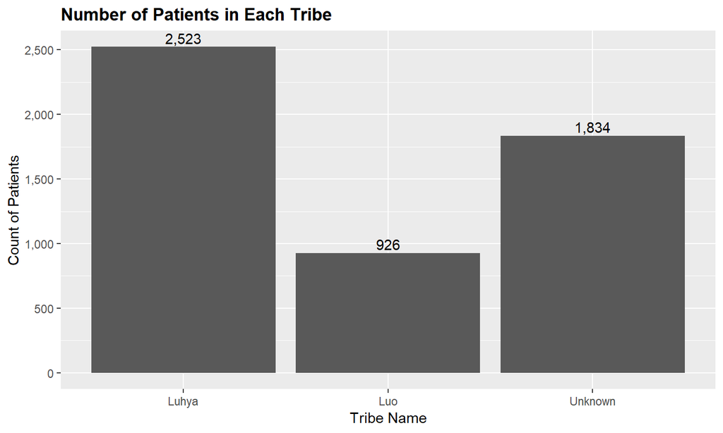

## Changes to the Data

- Combined all the tables and information discussed to the `mrs_encounter` table to see what a patients readings were at that point in time
- Removed anything that was not `ADULTRETURN` and one younger than 18

## Analysis

- Looked at T-Cells at different Stages of HIV (normal level is 500 - 1500)
- Immune system failure by reviewing other diagnosis at different stages of HIV

## Analysis (cont'd) - T-Cells

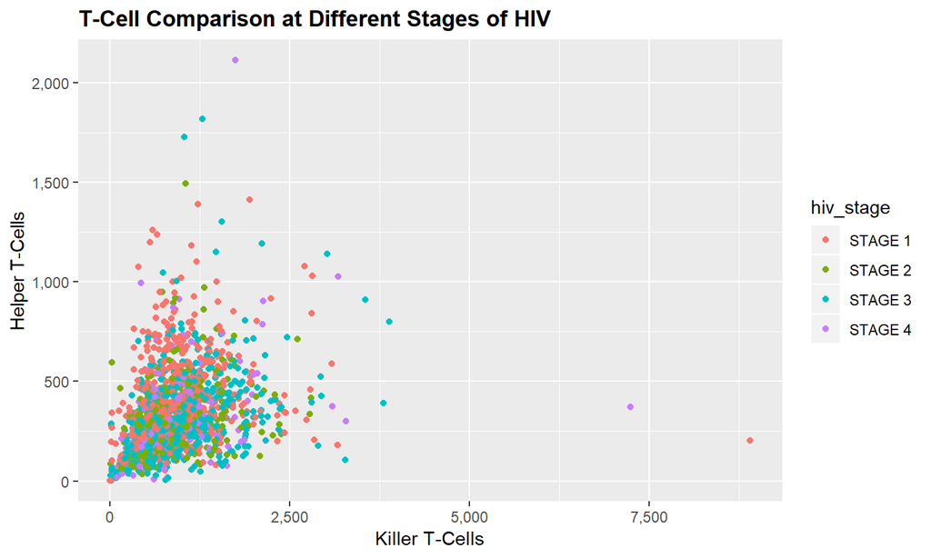

## Analysis (cont'd) - T-Cells

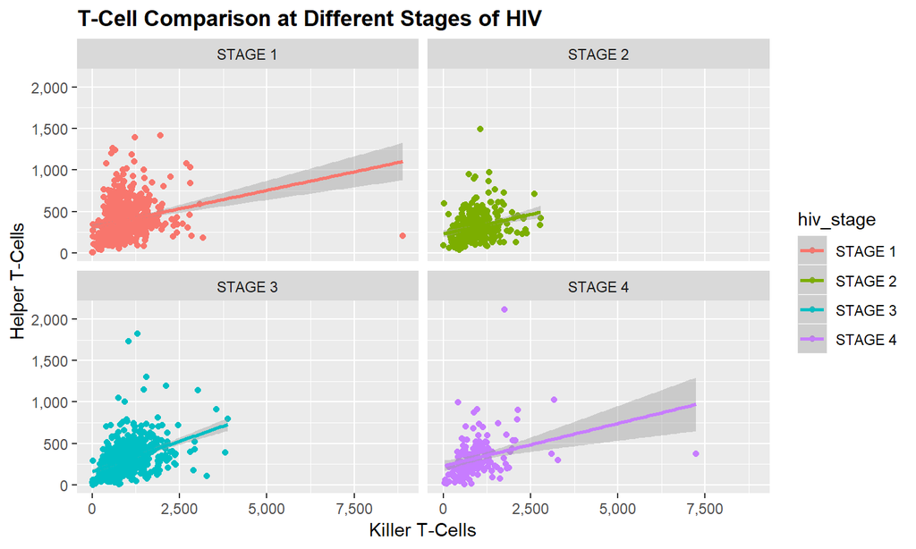

## Analysis (cont'd) - Other Diagnoses

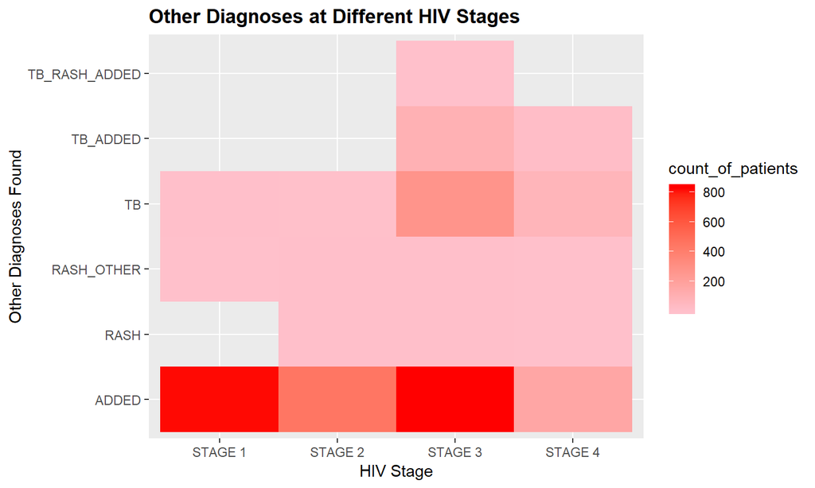

## Challenges

- Structure of Data
- Missing data
- Inconsistent Data
- Finding Useful Info
- Accuracy and Consistency

## Recommendations

- Improve the collection of data process. Figures for all Important variables to study.
- Remove data that is inconsistent or non-beneficial to the study.
- Create schema more convenient for analysis.